# Additional Coding HCF: Update #001

davegoblue

November 16, 2017

## Background

This document explores High Card Flush hands (see https://wizardofodds.com/games/high-card-flush/) to practice using techniques learned through multiple explorations.

## Analysis Approach

There are 52c7 potential hands in High Card Flush, though many of them are functionally equivalent to each other due to suits having no meaning in the game (spades and clubs have no inherent rank in comparison to the other). There are several steps to the analysis approach:

1. Compile the potential hands, suit independent, with their relative frequencies due to suits
2. Score each of the potential hands along the lines of a) Straight Flush, b) Flush, and c) Main Hand
3. Assess the degree that a given hand impacts the potential for the dealer hands (e.g., if a player has all 4 Aces then the dealer must not have any hand with an Ace)
4. Assess the expected value (EV) of each starting hand, and the overall game EV

### *Step 1: Compile Potential Hands*

#### *Step 1a: Verify Hands and Weights*

There are several flavors of potential hands depending on the length of the longest flush in the hand:

1. 7-0-0-0 - each has a weight of 4 (any of the potential suits could be the 7)
2. 6-1-0-0 - each has a weight of 12 (any of 4 suits as the 6 with any of 3 suits as the 1)
3. 5-2-0-0 - each has a weight of 12 (any of the 4 suits as the 5 with any of the 3 suits as the 2)
4. 5-1-1-0 - each has a weight of 12 (any of the 4 suits as the 5 with any of the 3 suits as the 0)
5. 4-3-0-0 - each has a weight of 12 (any of the 4 suits as the 4 with any of the 3 suits as the 3)
6. 4-2-1-0 - each has a weight of 24 (all suits independent)
7. 4-1-1-1 - each has a weight of 4 (any of the 4 suits as the 4)
8. 3-3-1-0 - each has a weight of 12 (any of the 4 suits as the 1 with any of the 3 suits as the 0)
9. 3-2-2-0 - each has a weight of 12 (any of the 4 suits as the 3 with any of the 3 suits as the 0)
10. 3-2-1-1 - each has a weight of 12 (any of the 4 suits as the 3 with any of the 3 suits as the 2)
11. 2-2-2-1 - each has a weight of 4 (any of the 4 suits as the 1)

Assessing the total number of potential hands, we have:

```r
startTime <- proc.time()

hndTypes <- matrix(data=-1L, nrow=11, ncol=2)

hndTypes[1, ] <- c(choose(13, 7), 4)
hndTypes[2, ] <- c(choose(13, 6) * choose(13, 1), 12)
hndTypes[3, ] <- c(choose(13, 5) * choose(13, 2), 12)
hndTypes[4, ] <- c(choose(13, 5) * choose(13, 1) * choose(13, 1), 12)
hndTypes[5, ] <- c(choose(13, 4) * choose(13, 3), 12)
hndTypes[6, ] <- c(choose(13, 4) * choose(13, 2) * choose(13, 1), 24)
hndTypes[7, ] <- c(choose(13, 4) * choose(13, 1) * choose(13, 1) * choose(13, 1), 4)
hndTypes[8, ] <- c(choose(13, 3) * choose(13, 3) * choose(13, 1), 12)
hndTypes[9, ] <- c(choose(13, 3) * choose(13, 2) * choose(13, 2), 12)
hndTypes[10, ] <- c(choose(13, 3) * choose(13, 2) * choose(13, 1) * choose(13, 1), 12)
hndTypes[11, ] <- c(choose(13, 2) * choose(13, 2) * choose(13, 2) * choose(13, 1), 4)

rowMult <- hndTypes[, 1] * hndTypes[, 2]
hndName <- c(7000,
             6100,
             5200, 5110,
             4300, 4210, 4111,
             3310, 3220, 3211,
             2221
             )
hndTypes <- cbind(hndTypes, rowMult, hndName)
colnames(hndTypes) <- c("# Hands", "Weight", "Total Hands", "Hand Class")

print(hndTypes)
```

```
##       # Hands Weight Total Hands Hand Class
##  [1,]    1716      4        6864       7000
##  [2,]   22308     12      267696       6100
##  [3,]  100386     12     1204632       5200
##  [4,]  217503     12     2610036       5110
##  [5,]  204490     12     2453880       4300
##  [6,]  725010     24    17400240       4210
##  [7,] 1570855      4     6283420       4111
##  [8,] 1063348     12    12760176       3310
##  [9,] 1740024     12    20880288       3220
## [10,] 3770052     12    45240624       3211
## [11,] 6169176      4    24676704       2221
```

```r
print(colSums(hndTypes))
```

```
##     # Hands      Weight Total Hands  Hand Class
##    15584868         120   133784560       47993
```

```r
print(choose(52, 7))
```

```
## [1] 133784560
```

```r
print(choose(52, 7) / colSums(hndTypes)[1])
```

```
## # Hands
## 8.58426
```

```r
proc.time() - startTime
```

```
##    user  system elapsed
##    0.06    0.00    0.06
```

As expected, the sum-product of the number of hands and the weights is 52c7 (133,784,560). Assessing this completely requires looking at 15,584,868 “unique” hands, a deflation of 8.6x compared to the full universe.

#### *Step 1b: First Order Approximation*

As a further simplifying factor, all of the 2-card suits and 1-card suits in HCF are not germaine to the game at a first approximation (they are relevant to the extent they impact other people’s potential hands from the same deck). This is due to a 9-High 3-card qualifying rule and bonuses that depend on 3+ straight flushes. As such, all flushes of length 2 and length 1 are identical to each other.

As such, updated weights include:

```r
startTime <- proc.time()

hndTypes <- matrix(data=-1L, nrow=11, ncol=2)

hndTypes[1, ] <- c(choose(13, 7), 4)
hndTypes[2, ] <- c(choose(13, 6), 4 * 39)  # Only the 6 cards matter, any of 4 suits, any of 39 kickers
hndTypes[3, ] <- c(choose(13, 5), 4 * 3 * choose(13, 2))  # Only the 5 cards matter, any of 4 suits, any of 13c2 kickers in any of 3 suits
hndTypes[4, ] <- c(choose(13, 5), 4 * 13 * 13 * choose(3, 2))  # Only the 5 cards matter, any of 4 suits, any of 13 kickers in each of 3c2 suits
hndTypes[5, ] <- c(choose(13, 4) * choose(13, 3), 12)  # All are of interest
hndTypes[6, ] <- c(choose(13, 4), 4 * choose(13, 2) * 3 * 13 * 2)  # Only the 4 cards matter, any of 4 suits, any of 13c2 kickers in any of 3 suits and then any of 13 kickers in any of the remaining 2 suits
hndTypes[7, ] <- c(choose(13, 4), 4 * 13 * 13 * 13)  # Only the 4 cards matter, any of 4 suits, any of 13 kickers in each of the 3 other suits
hndTypes[8, ] <- c(choose(13, 3) * choose(13, 3), choose(4, 2) * 26)  # Each of the 3 card triplets matter, available in any of 4c2 suits, with any of 26 additional cards for the kicker
hndTypes[9, ] <- c(choose(13, 3), 4 * choose(13, 2) * choose(13, 2) * choose(3, 2))  # Only the 3 cards matter, any of 4 suits, any of 13c2 kickers available in each of the 3c2 remaining suits
hndTypes[10, ] <- c(choose(13, 3), 4 * choose(13, 2) * 3 * 13 * 13)  # Only the 3 cards matter, any of 4 suits, any of 13c2 kickers in any of 3 suits, then any of 13 kickers in the other 2 suits
hndTypes[11, ] <- c(1, choose(13, 2) * choose(13, 2) * choose(13, 2) * choose(13, 1) * 4)  # No cards matter

rowMult <- hndTypes[, 1] * hndTypes[, 2]
hndName <- c(7000,
             6100,
             5200, 5110,
             4300, 4210, 4111,
             3310, 3220, 3211,
             2221
             )
hndTypes <- cbind(hndTypes, rowMult, hndName)
colnames(hndTypes) <- c("# Hands", "Weight", "Total Hands", "Hand Class")

print(hndTypes)
```

```
##       # Hands   Weight Total Hands Hand Class
##  [1,]    1716        4        6864       7000
##  [2,]    1716      156      267696       6100
##  [3,]    1287      936     1204632       5200
##  [4,]    1287     2028     2610036       5110
##  [5,]  204490       12     2453880       4300
##  [6,]     715    24336    17400240       4210
##  [7,]     715     8788     6283420       4111
##  [8,]   81796      156    12760176       3310
##  [9,]     286    73008    20880288       3220
## [10,]     286   158184    45240624       3211
## [11,]       1 24676704    24676704       2221
```

```r
print(colSums(hndTypes))
```

```
##     # Hands      Weight Total Hands  Hand Class
##      294295    24944312   133784560       47993
```

```r
print(choose(52, 7))
```

```
## [1] 133784560
```

```r
print(choose(52, 7) / colSums(hndTypes)[1])
```

```
##  # Hands
## 454.5934
```

```r
proc.time() - startTime
```

```
##    user  system elapsed
##    0.02    0.02    0.03
```

This will be a very helpful first-order approximation, since it reduces total hands for assessment to 294,295 (deflator of over 400x compared to the baseline 133.8 million hands). Almost all of the key hands for assessment are the 4-3-0-0 and 3-3-1-0 where there is a double assessment to be made.

#### *Step 1c: Create Hand Types by Number Per Suit*

All of the possible hands by “number of cards in the suit” are created. A full hand is simply the concatenation of one or more of these suited sub-hands in to a full 7-card hand. For purposes of creating these hands, the following ranks will be used:

- 2-10 will be given index 2-10 respectively
- J will be given index 11
- Q will be given index 12
- K will be given index 13
- A will be given index 14

The Ace is a high card in this game, with the exception that the Ace can play low for a straight flush. For example, A-2-3 is treated as an Ace-high hand with a 3-2 kicker in the main game, but is also treated as an A-2-3 3-card straight flush for the side bet. Scoring hands that contain index 14 will require an extra steo for that side bet.

Hands will be stored in descending order for easier comparisons. For example, A-Q-T-9 will be stored as 14-12-10-9 and will out-kick a hand like A-J-T-9 (stored as 14-11-10-9)

The hand types include:

```r
startTime <- proc.time()

hndType7 <- t(combn(14:2, 7))
hndType6 <- t(combn(14:2, 6))
hndType5 <- t(combn(14:2, 5))
hndType4 <- t(combn(14:2, 4))
hndType3 <- t(combn(14:2, 3))
hndType2 <- t(combn(14:2, 2))
hndType1 <- t(combn(14:2, 1))

cat(paste0("The 7-card hands should have: ", choose(13, 7), " combinations\t\tACTUAL: ", nrow(hndType7)))
```

```
## The 7-card hands should have: 1716 combinations      ACTUAL: 1716
```

```r
cat(paste0("The 6-card hands should have: ", choose(13, 6), " combinations\t\tACTUAL: ", nrow(hndType6)))
```

```
## The 6-card hands should have: 1716 combinations      ACTUAL: 1716
```

```r
cat(paste0("The 5-card hands should have: ", choose(13, 5), " combinations\t\tACTUAL: ", nrow(hndType5)))
```

```
## The 5-card hands should have: 1287 combinations      ACTUAL: 1287
```

```r
cat(paste0("The 4-card hands should have: ", choose(13, 4), " combinations\t\tACTUAL: ", nrow(hndType4)))
```

```
## The 4-card hands should have: 715 combinations       ACTUAL: 715
```

```r
cat(paste0("The 3-card hands should have: ", choose(13, 3), " combinations\t\tACTUAL: ", nrow(hndType3)))
```

```
## The 3-card hands should have: 286 combinations       ACTUAL: 286
```

```r
cat(paste0("The 2-card hands should have: ", choose(13, 2), " combinations\t\tACTUAL: ", nrow(hndType2)))
```

```
## The 2-card hands should have: 78 combinations        ACTUAL: 78
```

```r
cat(paste0("The 1-card hands should have: ", choose(13, 1), " combinations\t\tACTUAL: ", nrow(hndType1)))
```

```
## The 1-card hands should have: 13 combinations        ACTUAL: 13
```

```r
print(paste0("There are a total of ", nrow(hndType7) + nrow(hndType6) + nrow(hndType5) + nrow(hndType4) + nrow(hndType3) + nrow(hndType2) + nrow(hndType1), " hands to be scored"))
```

```
## [1] "There are a total of 5811 hands to be scored"
```

```r
proc.time() - startTime
```

```
##    user  system elapsed
##    0.05    0.00    0.05
```

So, by scoring and saving the values for 5,811 hands, all of the potential 7-card hands can be created and provided with an aggregate score.

### *Step 2: Score Hands*

First, we double check that the hand types have been sorted properly, and assign ranks based on that:

```r
hndChecker <- function(x) {
    hdRanks <- 1L
    firstHand <- TRUE
    for (eachRow in 1:nrow(x)) {
        eachHand <- x[eachRow, ]
        if (firstHand) {
            prevHand <- eachHand
            firstHand <- FALSE
        }
        else {
            curGTprev <- eachHand > prevHand
            prevGTcur <- prevHand > eachHand
            idxKey <- match(TRUE, prevGTcur)
            if (is.na(idxKey)) { stop("ERROR: Previous hand never greater than current hand")}
            if (idxKey == 1) {  }
            else {
                if (sum(curGTprev[1:(idxKey-1)]) > 0) { stop("ERROR: Current hand greater than previous hand")}
            }
            hdRanks <- c(hdRanks, eachRow)
            prevHand <- eachHand
        }
    }
    return(hdRanks)
}

startTime <- proc.time()

rkType7 <- hndChecker(hndType7)
rkType6 <- hndChecker(hndType6)
rkType5 <- hndChecker(hndType5)
rkType4 <- hndChecker(hndType4)
rkType3 <- hndChecker(hndType3)
rkType2 <- hndChecker(hndType2)
rkType1 <- hndChecker(hndType1)

print(identical(rkType7, 1:nrow(hndType7)))
```

```
## [1] TRUE
```

```r
print(identical(rkType6, 1:nrow(hndType6)))
```

```
## [1] TRUE
```

```r
print(identical(rkType5, 1:nrow(hndType5)))
```

```
## [1] TRUE
```

```r
print(identical(rkType4, 1:nrow(hndType4)))
```

```
## [1] TRUE
```

```r
print(identical(rkType3, 1:nrow(hndType3)))
```

```
## [1] TRUE
```

```r
print(identical(rkType2, 1:nrow(hndType2)))
```

```
## [1] TRUE
```

```r
print(identical(rkType1, 1:nrow(hndType1)))
```

```
## [1] TRUE
```

```r
proc.time() - startTime
```

```
##    user  system elapsed
##    0.06    0.00    0.06
```

So, the hands are properly sorted and ranked “as is”.

Next, the hands of 3+ cards are checked for whether they contain a 3+ card straight flush. For these purposes, the Ace (rank 14) needs to also be considered as an Ace low (rank 1).

```r
numSF <- function(x, ckAce=FALSE) {
    if (ckAce) {
        if (length(x) > 0 & x[1] == 14) { x <- c(x, 1) }
    }
    ckDummy <- paste0(1 + pmax(diff(x), -2), collapse="")

    if (length(grep("0", ckDummy)) == 0) { return(0L) }
    else if (length(grep("00", ckDummy)) == 0) { return(2L) }
    else if (length(grep("000", ckDummy)) == 0) { return(3L) }
    else if (length(grep("0000", ckDummy)) == 0) { return(4L) }
    else if (length(grep("00000", ckDummy)) == 0) { return(5L) }
    else if (length(grep("000000", ckDummy)) == 0) { return(6L) }
    else if (length(grep("000000", ckDummy)) == 1) { return(7L) }
    else { stop("Failure of NUM SF routine") }

    # else if (length(grep("000000", ckDummy)) > 0) { return(7L) }
    # else if (length(grep("00000", ckDummy)) > 0) { return(6L) }
    # else if (length(grep("0000", ckDummy)) > 0) { return(5L) }
    # else if (length(grep("000", ckDummy)) > 0) { return(4L) }
    # else if (length(grep("00", ckDummy)) > 0) { return(3L) }
    # else if (length(grep("0", ckDummy)) > 0) { return(2L) }

}

sfCheck <- function(x) {
    if (!(is.matrix(x) | is.vector(x))) { stop("SF Checker only for matrices or vectors") }
    sfType <- integer(0)
    if (is.matrix(x)) { nUse <- nrow(x) } else { nUse <- 1 }
    for (eachRow in seq_len(nUse)) {
        if (is.matrix(x)) { eachHand <- x[eachRow, ] } else { eachHand <- x }
        if (length(eachHand) > 0 & eachHand[1] == 14) { eachHand <- c(eachHand, 1) }
        sfType <- c(sfType, numSF(eachHand))
    }
    return(sfType)
}

startTime <- proc.time()

sfType7 <- sfCheck(hndType7)
sfType6 <- sfCheck(hndType6)
sfType5 <- sfCheck(hndType5)
sfType4 <- sfCheck(hndType4)
sfType3 <- sfCheck(hndType3)
sfType2 <- sfCheck(hndType2)
sfType1 <- sfCheck(hndType1)

vecCount <- c(rep(7, length(sfType7)), rep(6, length(sfType6)), rep(5, length(sfType5)),
              rep(4, length(sfType4)), rep(3, length(sfType3)), rep(2, length(sfType2)),
              rep(1, length(sfType1))
             )
vecType <- c(sfType7, sfType6, sfType5, sfType4, sfType3, sfType2, sfType1)

table(vecCount, vecType)
```

```
##         vecType
## vecCount   0   2   3   4   5   6   7
##        1  13   0   0   0   0   0   0
##        2  65  13   0   0   0   0   0
##        3 156 118  12   0   0   0   0
##        4 182 424  98  11   0   0   0
##        5  91 756 351  79  10   0   0
##        6  13 700 687 245  62   9   0
##        7   0 318 755 426 162  47   8
```

```r
round(prop.table(table(vecCount, vecType), 1), 3)
```

```
##         vecType
## vecCount     0     2     3     4     5     6     7
##        1 1.000 0.000 0.000 0.000 0.000 0.000 0.000
##        2 0.833 0.167 0.000 0.000 0.000 0.000 0.000
##        3 0.545 0.413 0.042 0.000 0.000 0.000 0.000
##        4 0.255 0.593 0.137 0.015 0.000 0.000 0.000
##        5 0.071 0.587 0.273 0.061 0.008 0.000 0.000
##        6 0.008 0.408 0.400 0.143 0.036 0.005 0.000
##        7 0.000 0.185 0.440 0.248 0.094 0.027 0.005
```

```r
proc.time() - startTime
```

```
##    user  system elapsed
##    0.36    0.00    0.36
```

### *Step 3: Assess Cross-Hand Impact*

Since multiple hands can be played from the same 52-card shoe, the cards present in one hand are by definition not present in any other hand. So, for example, if a player holds all 4 Aces, then the dealer cannot have any hand that includes an Ace.

First, the impact of a single hand on all the other hands is considered to modify the weights originally calculated in Step 1. Notably, given the existence of a single 7-card hand, the remaining hands should have 45c7 possibilities (45.4 million).

As a basic starting point, we give the player a randomly selected 4-2-1 hand:

```r
startTime <- proc.time()

set.seed(1711210734)

rnd4 <- sample(seq_len(nrow(hndType4)), 1)
rnd2 <- sample(seq_len(nrow(hndType2)), 1)
rnd1 <- sample(seq_len(nrow(hndType1)), 1)

hnd4 <- hndType4[rnd4, ]
hnd2 <- hndType2[rnd2, ]
hnd1 <- hndType1[rnd1, ]

cat("\nSuit 1: ", hnd4, "\t\tSuit2: ", hnd2, "\t\tSuit3: ", hnd1, "\n\n")
```

```
##
## Suit 1:  13 12 6 4       Suit2:  11 6        Suit3:  9
```

```r
proc.time() - startTime
```

```
##    user  system elapsed
##    0.02    0.00    0.01
```

This hand includes K(1)-Q(1)-J(2)-9(3)-6(1)-6(2)-4(1), making each of these ranks (and especially the 6) less likely to be in the dealer hand.

Next, a routine is written to calculate the number of available hands, and to compare it to the baseline:

```r
library(dplyr)
countHandCombos <- function(n1, n2, n3, n4, a1=13, a2=13, a3=13, a4=13, kF=keyFrame, nines=NULL) {
    hndCounts <- rep(NA_integer_, 24)
    egtCounts <- rep(NA_integer_, 24)

    keyMatrix <- t(apply(keyFrame, 1, FUN=function(x) { c(n1, n2, n3, n4)[x] }))
    useMatrix <- keyMatrix[!duplicated(keyMatrix), ]

    if (!(nrow(useMatrix) %in% c(4, 12, 24))) { stop("ERROR: Wrong Number of Rows!") }

    if (!is.null(nines)) {
        b1 = a1 - nines[1]
        b2 = a2 - nines[2]
        b3 = a3 - nines[3]
        b4 = a4 - nines[4]
    }

    for (intCtr in 1:nrow(useMatrix)) {
        rowData <- useMatrix[intCtr, ]
        hndCounts[intCtr] <- choose(a1, rowData[1]) * choose(a2, rowData[2]) *
            choose(a3, rowData[3]) * choose(a4, rowData[4])
        if (!is.null(nines)) {
            if (max(n1, n2, n3, n4) > 3) {
                egtCounts[intCtr] <- 0
            } else if (max(n1, n2, n3, n4) == 2) {
                egtCounts[intCtr] <- hndCounts[intCtr]
            } else {
                egtCounts[intCtr] <- choose(ifelse(rowData[1] == 3, b1, a1), rowData[1]) *
                    choose(ifelse(rowData[2] == 3, b2, a2), rowData[2]) *
                    choose(ifelse(rowData[3] == 3, b3, a3), rowData[3]) *
                    choose(ifelse(rowData[4] == 3, b4, a4), rowData[4])
            }
        }
    }

    if (is.null(nines)) { return(hndCounts) }
    else { return(c(hndCounts, egtCounts)) }

}

startTime <- proc.time()

m1 <- integer(0)
m2 <- integer(0)
m3 <- integer(0)
m4 <- integer(0)

for (intCtr in 0:23) {
    pos1 <- 1 + (intCtr %/% 6)
    pos2 <- 1 + (intCtr %% 6) %/% 2
    pos3 <- 1 + (intCtr %% 2)
    # cat("\n", pos1, " ", pos2, " ", pos3)

    mod2 <- setdiff(1:4, pos1)[pos2]
    mod3 <- setdiff(1:4, c(pos1, mod2))[pos3]
    mod4 <- setdiff(1:4, c(pos1, mod2, mod3))
    # cat("\n", pos1, " ", mod2, " ", mod3, " ", mod4)

    m1 <- c(m1, pos1)
    m2 <- c(m2, mod2)
    m3 <- c(m3, mod3)
    m4 <- c(m4, mod4)

}

keyFrame <- data.frame(m1, m2, m3, m4)
print(keyFrame)
```

```
##    m1 m2 m3 m4
## 1   1  2  3  4
## 2   1  2  4  3
## 3   1  3  2  4
## 4   1  3  4  2
## 5   1  4  2  3
## 6   1  4  3  2
## 7   2  1  3  4
## 8   2  1  4  3
## 9   2  3  1  4
## 10  2  3  4  1
## 11  2  4  1  3
## 12  2  4  3  1
## 13  3  1  2  4
## 14  3  1  4  2
## 15  3  2  1  4
## 16  3  2  4  1
## 17  3  4  1  2
## 18  3  4  2  1
## 19  4  1  2  3
## 20  4  1  3  2
## 21  4  2  1  3
## 22  4  2  3  1
## 23  4  3  1  2
## 24  4  3  2  1
```

```r
proc.time() - startTime
```

```
##    user  system elapsed
##       0       0       0
```

For comparison to the baseline, a list of potential (n1, n2, n3, n4) is created:

```r
startTime <- proc.time()

n1234List <- list(c(7, 0, 0, 0),
                  c(6, 1, 0, 0),
                  c(5, 2, 0, 0), c(5, 1, 1, 0),
                  c(4, 3, 0, 0), c(4, 2, 1, 0), c(4, 1, 1, 1),
                  c(3, 3, 1, 0), c(3, 2, 2, 0), c(3, 2, 1, 1),
                  c(2, 2, 2, 1)
                  )

baseAvlData <- sapply(n1234List, FUN=function(x) {
    countHandCombos(n1=x[1], n2=x[2], n3=x[3], n4=x[4], kF=keyFrame)
    }
)

baseTotals <- colSums(baseAvlData, na.rm=TRUE)
baseTotals
```

```
##  [1]     6864   267696  1204632  2610036  2453880 17400240  6283420
##  [8] 12760176 20880288 45240624 24676704
```

```r
all.equal(sum(baseTotals), choose(52, 7))
```

```
## [1] TRUE
```

```r
proc.time() - startTime
```

```
##    user  system elapsed
##    0.03    0.00    0.03
```

And then, the sample hand from above is assessed:

```r
startTime <- proc.time()

cat("\nThe hand to be assessed is SUIT 1: ", hnd4, "\t\tSUIT 2: ", hnd2, "\t\tSUIT3: ", hnd1, "\n\n")
```

```
##
## The hand to be assessed is SUIT 1:  13 12 6 4        SUIT 2:  11 6       SUIT3:  9
```

```r
avNums <- 13 - c(length(hnd4), length(hnd2), length(hnd1), length(integer(0)))

newAvlData <- sapply(n1234List, FUN=function(x) {
    countHandCombos(n1=x[1], n2=x[2], n3=x[3], n4=x[4],
                    a1=avNums[1], a2=avNums[2], a3=avNums[3], a4=avNums[4],
                    kF=keyFrame
                    )
    }
)

newTotals <- colSums(newAvlData, na.rm=TRUE)
newTotals
```

```
##  [1]     2874   104136   444141   950949   879406  6076053  2166021
##  [8]  4390562  7083648 15142842  8138988
```

```r
all.equal(sum(newTotals), choose(45, 7))
```

```
## [1] TRUE
```

```r
proc.time() - startTime
```

```
##    user  system elapsed
##    0.02    0.00    0.02
```

Percentages and likelihoods can also be compared:

```r
startTime <- proc.time()

tmpFrame <- data.frame(baseTotals, newTotals)
tmpFrame <- tmpFrame %>%
    mutate(basePct = baseTotals/sum(baseTotals), newPct = newTotals/sum(newTotals), relPct = newPct/basePct)
round(tmpFrame, 6)
```

```
##    baseTotals newTotals  basePct   newPct   relPct
## 1        6864      2874 0.000051 0.000063 1.234396
## 2      267696    104136 0.002001 0.002295 1.146843
## 3     1204632    444141 0.009004 0.009787 1.086955
## 4     2610036    950949 0.019509 0.020955 1.074128
## 5     2453880    879406 0.018342 0.019379 1.056529
## 6    17400240   6076053 0.130062 0.133894 1.029465
## 7     6283420   2166021 0.046967 0.047731 1.016276
## 8    12760176   4390562 0.095379 0.096752 1.014398
## 9    20880288   7083648 0.156074 0.156098 1.000151
## 10   45240624  15142842 0.338160 0.333693 0.986788
## 11   24676704   8138988 0.184451 0.179353 0.972363
```

```r
round(colSums(tmpFrame %>% select(basePct, newPct)), 6)
```

```
## basePct  newPct
##       1       1
```

```r
proc.time() - startTime
```

```
##    user  system elapsed
##    0.03    0.00    0.03
```

As well, the likelihood of a qualifying hand (3-card 9-high or better) can be assessed:

```r
startTime <- proc.time()

baseNinesData <- sapply(n1234List, FUN=function(x) {
    countHandCombos(n1=x[1], n2=x[2], n3=x[3], n4=x[4],
                    kF=keyFrame, nines=c(6, 6, 6, 6)
                    )
    }
)

baseNinesTotals <- colSums(baseNinesData[1:24, ], na.rm=TRUE)
names(baseNinesTotals) <- sapply(n1234List, FUN=paste0, collapse="-")
baseNinesTotals
```

```
##  7-0-0-0  6-1-0-0  5-2-0-0  5-1-1-0  4-3-0-0  4-2-1-0  4-1-1-1  3-3-1-0
##     6864   267696  1204632  2610036  2453880 17400240  6283420 12760176
##  3-2-2-0  3-2-1-1  2-2-2-1
## 20880288 45240624 24676704
```

```r
all.equal(sum(baseNinesTotals), choose(52, 7))
```

```
## [1] TRUE
```

```r
colSums(baseNinesData[25:48, ], na.rm=TRUE)
```

```
##  [1]        0        0        0        0        0        0        0
##  [8]   191100  2555280  5536440 24676704
```

```r
colSums(baseNinesData[25:48, ], na.rm=TRUE) / baseNinesTotals
```

```
##    7-0-0-0    6-1-0-0    5-2-0-0    5-1-1-0    4-3-0-0    4-2-1-0
## 0.00000000 0.00000000 0.00000000 0.00000000 0.00000000 0.00000000
##    4-1-1-1    3-3-1-0    3-2-2-0    3-2-1-1    2-2-2-1
## 0.00000000 0.01497628 0.12237762 0.12237762 1.00000000
```

```r
baseNinesQual <- baseNinesTotals - colSums(baseNinesData[25:48, ], na.rm=TRUE)
baseNinesQual
```

```
##  7-0-0-0  6-1-0-0  5-2-0-0  5-1-1-0  4-3-0-0  4-2-1-0  4-1-1-1  3-3-1-0
##     6864   267696  1204632  2610036  2453880 17400240  6283420 12569076
##  3-2-2-0  3-2-1-1  2-2-2-1
## 18325008 39704184        0
```

```r
sum(baseNinesQual) / sum(baseNinesTotals)
```

```
## [1] 0.7536373
```

```r
cat("\nThe hand to be assessed is SUIT 1: ", hnd4, "\t\tSUIT 2: ", hnd2, "\t\tSUIT3: ", hnd1, "\n\n")
```

```
##
## The hand to be assessed is SUIT 1:  13 12 6 4        SUIT 2:  11 6       SUIT3:  9
```

```r
avNums <- 13 - c(length(hnd4), length(hnd2), length(hnd1), length(integer(0)))
ninePlus <- 6 - c(sum(hnd4 >= 9), sum(hnd2 >= 9), sum(hnd1 >= 9), 0)


newNinesData <- sapply(n1234List, FUN=function(x) {
    countHandCombos(n1=x[1], n2=x[2], n3=x[3], n4=x[4],
                    a1=avNums[1], a2=avNums[2], a3=avNums[3], a4=avNums[4],
                    kF=keyFrame, nines=ninePlus
                    )
    }
)

newNinesTotals <- colSums(newNinesData[1:24, ], na.rm=TRUE)
names(newNinesTotals) <- sapply(n1234List, FUN=paste0, collapse="-")
newNinesTotals
```

```
##  7-0-0-0  6-1-0-0  5-2-0-0  5-1-1-0  4-3-0-0  4-2-1-0  4-1-1-1  3-3-1-0
##     2874   104136   444141   950949   879406  6076053  2166021  4390562
##  3-2-2-0  3-2-1-1  2-2-2-1
##  7083648 15142842  8138988
```

```r
all.equal(sum(newNinesTotals), choose(45, 7))
```

```
## [1] TRUE
```

```r
colSums(newNinesData[25:48, ], na.rm=TRUE)
```

```
##  [1]       0       0       0       0       0       0       0   76050
##  [9]  934560 1996965 8138988
```

```r
colSums(newNinesData[25:48, ], na.rm=TRUE) / newNinesTotals
```

```
##    7-0-0-0    6-1-0-0    5-2-0-0    5-1-1-0    4-3-0-0    4-2-1-0
## 0.00000000 0.00000000 0.00000000 0.00000000 0.00000000 0.00000000
##    4-1-1-1    3-3-1-0    3-2-2-0    3-2-1-1    2-2-2-1
## 0.00000000 0.01732124 0.13193202 0.13187518 1.00000000
```

```r
newNinesQual <- newNinesTotals - colSums(newNinesData[25:48, ], na.rm=TRUE)
newNinesQual
```

```
##  7-0-0-0  6-1-0-0  5-2-0-0  5-1-1-0  4-3-0-0  4-2-1-0  4-1-1-1  3-3-1-0
##     2874   104136   444141   950949   879406  6076053  2166021  4314512
##  3-2-2-0  3-2-1-1  2-2-2-1
##  6149088 13145877        0
```

```r
sum(newNinesQual) / sum(newNinesTotals)
```

```
## [1] 0.7543707
```

```r
proc.time() - startTime
```

```
##    user  system elapsed
##     0.1     0.0     0.1
```

Further, hand likelihoods can be assessed based on many other hands having been eliminated:

```r
startTime <- proc.time()

hnd1 <- list(c(), c(14, 12, 10, 4, 3), c(14), c(14))
hnd2 <- list(c(12, 11, 10, 9), c(5), c(8), c(10))
hnd3 <- list(c(14, 13), c(13, 11), c(13, 12, 11), c())

hndTot <- vector("list", 4)
for (intCtr in 1:4) {
    fullCards <- c(hnd1[[intCtr]], hnd2[[intCtr]], hnd3[[intCtr]])
    if (!all.equal(fullCards, unique(fullCards))) { stop("Problem with duplicate cards") }
    hndTot[[intCtr]] <- fullCards
}

avNums <- 13 - sapply(hndTot, FUN=length)
ninePlus <- 6 - sapply(hndTot, FUN=function(x) { sum(x >= 9) })

testData <- sapply(n1234List, FUN=function(x) {
    countHandCombos(n1=x[1], n2=x[2], n3=x[3], n4=x[4],
                    a1=avNums[1], a2=avNums[2], a3=avNums[3], a4=avNums[4],
                    kF=keyFrame, nines=ninePlus
                    )
    }
)

testTotals <- colSums(testData[1:24, ], na.rm=TRUE)
names(testTotals) <- sapply(n1234List, FUN=paste0, collapse="-")
testTotals
```

```
## 7-0-0-0 6-1-0-0 5-2-0-0 5-1-1-0 4-3-0-0 4-2-1-0 4-1-1-1 3-3-1-0 3-2-2-0
##     339   10052   34131   73938   57395  388785  137830  258795  400890
## 3-2-1-1 2-2-2-1
##  840840  426580
```

```r
all.equal(sum(testTotals), choose(31, 7))
```

```
## [1] TRUE
```

```r
colSums(testData[25:48, ], na.rm=TRUE)
```

```
##  [1]      0      0      0      0      0      0      0  41725 172112 350336
## [11] 426580
```

```r
colSums(testData[25:48, ], na.rm=TRUE) / testTotals
```

```
##   7-0-0-0   6-1-0-0   5-2-0-0   5-1-1-0   4-3-0-0   4-2-1-0   4-1-1-1
## 0.0000000 0.0000000 0.0000000 0.0000000 0.0000000 0.0000000 0.0000000
##   3-3-1-0   3-2-2-0   3-2-1-1   2-2-2-1
## 0.1612280 0.4293248 0.4166500 1.0000000
```

```r
testQual <- testTotals - colSums(testData[25:48, ], na.rm=TRUE)
testQual
```

```
## 7-0-0-0 6-1-0-0 5-2-0-0 5-1-1-0 4-3-0-0 4-2-1-0 4-1-1-1 3-3-1-0 3-2-2-0
##     339   10052   34131   73938   57395  388785  137830  217070  228778
## 3-2-1-1 2-2-2-1
##  490504       0
```

```r
sum(testQual) / sum(testTotals)
```

```
## [1] 0.6232269
```

```r
proc.time() - startTime
```

```
##    user  system elapsed
##    0.04    0.00    0.04
```

And, with even greater eliminations:

```r
startTime <- proc.time()

hndTot <- list(c(14, 13, 12, 10, 8, 6, 4, 2),
               c(13, 12, 11, 9, 7, 5, 3, 2),
               c(14, 13, 12, 11, 9, 6, 4, 3, 2),
               c(13, 12, 11, 10, 9, 8, 7, 6, 5, 3)
               )
avNums <- 13 - sapply(hndTot, FUN=length)
ninePlus <- 6 - sapply(hndTot, FUN=function(x) { sum(x >= 9) })

testData <- sapply(n1234List, FUN=function(x) {
    countHandCombos(n1=x[1], n2=x[2], n3=x[3], n4=x[4],
                    a1=avNums[1], a2=avNums[2], a3=avNums[3], a4=avNums[4],
                    kF=keyFrame, nines=ninePlus
                    )
    }
)

testTotals <- colSums(testData[1:24, ], na.rm=TRUE)
names(testTotals) <- sapply(n1234List, FUN=paste0, collapse="-")
testTotals
```

```
## 7-0-0-0 6-1-0-0 5-2-0-0 5-1-1-0 4-3-0-0 4-2-1-0 4-1-1-1 3-3-1-0 3-2-2-0
##       0       0      38      94     171    1640     675    1560    3020
## 3-2-1-1 2-2-2-1
##    7450    4800
```

```r
all.equal(sum(testTotals), choose(17, 7))
```

```
## [1] TRUE
```

```r
colSums(testData[25:48, ], na.rm=TRUE)
```

```
##  [1]    0    0    0    0    0    0    0   23  376  915 4800
```

```r
colSums(testData[25:48, ], na.rm=TRUE) / testTotals
```

```
##    7-0-0-0    6-1-0-0    5-2-0-0    5-1-1-0    4-3-0-0    4-2-1-0
##        NaN        NaN 0.00000000 0.00000000 0.00000000 0.00000000
##    4-1-1-1    3-3-1-0    3-2-2-0    3-2-1-1    2-2-2-1
## 0.00000000 0.01474359 0.12450331 0.12281879 1.00000000
```

```r
testQual <- testTotals - colSums(testData[25:48, ], na.rm=TRUE)
testQual
```

```
## 7-0-0-0 6-1-0-0 5-2-0-0 5-1-1-0 4-3-0-0 4-2-1-0 4-1-1-1 3-3-1-0 3-2-2-0
##       0       0      38      94     171    1640     675    1537    2644
## 3-2-1-1 2-2-2-1
##    6535       0
```

```r
sum(testQual) / sum(testTotals)
```

```
## [1] 0.6856232
```

```r
proc.time() - startTime
```

```
##    user  system elapsed
##    0.06    0.00    0.06
```

Next, all of the hand types are scored for straight flush, flush, rank within type, and qualification:

```r
startTime <- proc.time()

hndType <- vector("list", 7)
for (intCtr in 1:7) {
    hndType[[intCtr]] <- get(paste0("hndType", intCtr))
}

hndScore <- vector("list", 7)
# Score for straight flush, flush, overall rank, and qualification
hndRank <- sum(sapply(hndType, FUN=nrow))
for (intCtr in 7:1) {
    coreData <- hndType[[intCtr]]
    maxCard <- apply(coreData, 1, FUN=max)
    outData <- matrix(data=NA, nrow=nrow(coreData), ncol=4)
    outData[, 1] <- intCtr  # Number of Flushes
    outData[, 2] <- sfCheck(coreData)  # Number of Straight Flushes
    outData[, 3] <- hndRank:(hndRank - nrow(coreData) + 1)  # Rank (higher better) since hands already sorted
    outData[, 4] <- FALSE  # Set the qualification
    if (intCtr > 3) {
        outData[, 4] <- TRUE
    } else if (intCtr == 3) {
        outData[, 4] <- (maxCard >= 9)
    }
    hndRank <- hndRank - nrow(coreData)
    hndScore[[intCtr]] <- outData
}

# Check that ranks make sense
sapply(hndScore, FUN=function(x) { y=x[, 1]; return(c(x[1, 1], min(y), max(y))) } )
```

```
##      [,1] [,2] [,3] [,4] [,5] [,6] [,7]
## [1,]    1    2    3    4    5    6    7
## [2,]    1    2    3    4    5    6    7
## [3,]    1    2    3    4    5    6    7
```

```r
sapply(hndScore, FUN=function(x) { y=x[, 2]; return(c(x[1, 1], min(y), max(y))) } )
```

```
##      [,1] [,2] [,3] [,4] [,5] [,6] [,7]
## [1,]    1    2    3    4    5    6    7
## [2,]    0    0    0    0    0    0    2
## [3,]    0    2    3    4    5    6    7
```

```r
sapply(hndScore, FUN=function(x) { y=x[, 3]; return(c(x[1, 1], min(y), max(y))) } )
```

```
##      [,1] [,2] [,3] [,4] [,5] [,6] [,7]
## [1,]    1    2    3    4    5    6    7
## [2,]    1   14   92  378 1093 2380 4096
## [3,]   13   91  377 1092 2379 4095 5811
```

```r
sapply(hndScore, FUN=function(x) { y=x[, 4]; return(c(x[1, 1], sum(y==1), sum(y==0))) } )
```

```
##      [,1] [,2] [,3] [,4] [,5] [,6] [,7]
## [1,]    1    2    3    4    5    6    7
## [2,]    0    0  251  715 1287 1716 1716
## [3,]   13   78   35    0    0    0    0
```

```r
proc.time() - startTime
```

```
##    user  system elapsed
##    0.61    0.00    0.62
```

Next, a revised method is taken to draw a sample of hands, leveraging that all of the hands by number of cards, as well as their relevant scores, have already been created:

```r
startTime <- proc.time()

nDeal <- 4000000
nShow <- 20
set.seed(1711290801)

# Create all the combinations with their weights
mtxTemp <- data.matrix(expand.grid(7:2, 3:0, 2:0, 1:0))
colnames(mtxTemp) <- NULL
isOK <- apply(mtxTemp, 1,
              FUN=function(x) { (sum(x) == 7 & (x[1] >= x[2]) & (x[2] >= x[3]) & (x[3] >= x[4])) }
              )
mtxTemp <- mtxTemp[isOK, ]
mtxTemp <- mtxTemp[order(mtxTemp[, 1], mtxTemp[, 2], mtxTemp[, 3], mtxTemp[, 4], decreasing=TRUE), ]

# mtxTemp <- matrix(data=c(7, 0, 0, 0,
#                          6, 1, 0, 0,
#                          5, 2, 0, 0,
#                          5, 1, 1, 0,
#                          4, 3, 0, 0,
#                          4, 2, 1, 0,
#                          4, 1, 1, 1,
#                          3, 3, 1, 0,
#                          3, 2, 2, 0,
#                          3, 2, 1, 1,
#                          2, 2, 2, 1),
#                   ncol=4, byrow=TRUE
#                   )
mtxWeights <- hndTypes[, "Total Hands"]
cbind(mtxTemp, mtxWeights)
```

```
##               mtxWeights
##  [1,] 7 0 0 0       6864
##  [2,] 6 1 0 0     267696
##  [3,] 5 2 0 0    1204632
##  [4,] 5 1 1 0    2610036
##  [5,] 4 3 0 0    2453880
##  [6,] 4 2 1 0   17400240
##  [7,] 4 1 1 1    6283420
##  [8,] 3 3 1 0   12760176
##  [9,] 3 2 2 0   20880288
## [10,] 3 2 1 1   45240624
## [11,] 2 2 2 1   24676704
```

```r
permRows <- expand.grid(1:4, 1:4, 1:4, 1:4)
isOK <- apply(permRows, 1, FUN=function(x) { length(x) == length(unique(x)) })
permRows <- matrix(as.vector(data.matrix(permRows[isOK, ])), ncol=4, byrow=FALSE)
permRows <- permRows[order(permRows[, 1], permRows[, 2], permRows[, 3], permRows[, 4]), ]

# permRows <- matrix(data=c(1, 2, 3, 4,
#                           1, 2, 4, 3,
#                           1, 3, 2, 4,
#                           1, 3, 4, 2,
#                           1, 4, 2, 3,
#                           1, 4, 3, 2,
#                           2, 1, 3, 4,
#                           2, 1, 4, 3,
#                           2, 3, 1, 4,
#                           2, 3, 4, 1,
#                           2, 4, 1, 3,
#                           2, 4, 3, 1,
#                           3, 1, 2, 4,
#                           3, 1, 4, 2,
#                           3, 2, 1, 4,
#                           3, 2, 4, 1,
#                           3, 4, 1, 2,
#                           3, 4, 2, 1,
#                           4, 1, 2, 3,
#                           4, 1, 3, 2,
#                           4, 2, 1, 3,
#                           4, 2, 3, 1,
#                           4, 3, 1, 2,
#                           4, 3, 2, 1),
#                    ncol=4, byrow=TRUE)
permRows
```

```
##       [,1] [,2] [,3] [,4]
##  [1,]    1    2    3    4
##  [2,]    1    2    4    3
##  [3,]    1    3    2    4
##  [4,]    1    3    4    2
##  [5,]    1    4    2    3
##  [6,]    1    4    3    2
##  [7,]    2    1    3    4
##  [8,]    2    1    4    3
##  [9,]    2    3    1    4
## [10,]    2    3    4    1
## [11,]    2    4    1    3
## [12,]    2    4    3    1
## [13,]    3    1    2    4
## [14,]    3    1    4    2
## [15,]    3    2    1    4
## [16,]    3    2    4    1
## [17,]    3    4    1    2
## [18,]    3    4    2    1
## [19,]    4    1    2    3
## [20,]    4    1    3    2
## [21,]    4    2    1    3
## [22,]    4    2    3    1
## [23,]    4    3    1    2
## [24,]    4    3    2    1
```

```r
mtxSuits <- matrix(data=NA, nrow=nrow(mtxTemp)*nrow(permRows), ncol=4)
wgtSuits <- vector("numeric", nrow(mtxSuits))
idxCur <- 1
for (ctrA in 1:nrow(mtxTemp)) {
    for (ctrB in 1:nrow(permRows)) {
        mtxSuits[idxCur, ] <- mtxTemp[ctrA, permRows[ctrB, ]]
        wgtSuits[idxCur] <- mtxWeights[ctrA] / nrow(permRows)
        idxCur <- idxCur + 1
    }
}

# Create the suits by hand
tmpX <- sample(1:nrow(mtxSuits), nDeal, replace=TRUE, prob=wgtSuits)
suitNums <- mtxSuits[tmpX, ]

# Determine the suitedness of the hand
# suitPick <- matrix(data=NA_integer_, nrow=nDeal, ncol=7)
# for (intCtr in 1:nrow(suitPick)) {
#     suitPick[intCtr, ] <- sample(rep(1:4, 13), 7, replace=FALSE)
# }
# ckNums <- function(x) {
#     n1 <- sum(x == 1)
#     n2 <- sum(x == 2)
#     n3 <- sum(x == 3)
#     n4 <- sum(x == 4)
#     if (sum(n1, n2, n3, n4) != length(x)) { stop("ERROR: Count mismatches") }
#     return(c(n1, n2, n3, n4))
# }
# suitNums <- t(apply(suitPick, 1, FUN=ckNums))

proc.time() - startTime
```

```
##    user  system elapsed
##    0.53    0.02    0.54
```

And, the sample of hands are then scored and ranked:

```r
startTime <- proc.time()

# Pick out multiple hands
getCards <- function(x, lenPart=2000000) {
    nPart <- ceiling(length(x) / lenPart)
    slicePart <- vector("list", nPart)
    for (intCtr in 1:nPart) {
        slicePart[[intCtr]] <- (lenPart * (intCtr-1) + 1):(min(length(x), lenPart * intCtr))
    }
    # useData <- matrix(data=NA_integer_, nrow=4, ncol=0)
    useData <- matrix(data=NA_integer_, nrow=2, ncol=0)  # Grab flush length and qualification later
    for (thisSlice in slicePart) {
        y <- as.vector(t(x))[thisSlice]
        # tmpMtx <- matrix(data=rep(NA_integer_, 4 * length(y)), ncol=4)
        # tmpMtx[y == 0, ] <- c(0L, 0L, 0L, 0L)
        tmpMtx <- matrix(data=rep(NA_integer_, 2 * length(y)), ncol=2)
        tmpMtx[y == 0, ] <- c(0L, 0L)
        for (intCtr in 1:7) {
            z <- (y == intCtr)
            # useList <- hndScore[[intCtr]]
            useList <- hndScore[[intCtr]][, 2:3]
            tmpMtx[z, ] <- useList[sample(nrow(useList), sum(z), replace=TRUE), ]
        }
        # tmpArray <- array(as.vector(t(tmpMtx)), c(4, 4, length(tmpMtx) / 16))
        tmpArray <- array(as.vector(t(tmpMtx)), c(2, 4, length(tmpMtx) / 8))
        useData <- cbind(useData, apply(tmpArray, c(1, 3), FUN=max))
    }
    return(useData)
}

# Pick out a single hand
# getCards <- function(x) {
#     tmpVec <- numeric(0)
#     for (y in x) {
#         if (y == 0) { tmpVec <- c(tmpVec, 0, 0, 0, 0) }
#         else {
#             useScore <- hndScore[[y]]
#             tmpVec <- c(tmpVec, useScore[sample(nrow(useScore), 1), ])
#         }
#     }
#     return(tmpVec)
# }

set.seed(1712180754)
nTest <- nDeal
nPick <- sort(sample(nDeal, nTest, replace=FALSE))
storeStat <- matrix(data=NA_integer_, nrow=nTest, ncol=4)
storeStat[, 2:3] <- t(getCards(suitNums[nPick, ])) # Use function for SF and Hand Value

# Find/add dealer qualifier
txtQual <- "9-3-2"
keyQual <- which(apply(hndType[[3]], 1, FUN=paste0, collapse="-") == txtQual)
keyScore <- hndScore[[3]][keyQual, 3]
cat("\n\nDealer will play if equal to or better than ", txtQual, " which occurs at score index ", keyScore)
```

```
##
##
## Dealer will play if equal to or better than  9-3-2  which occurs at score index  127
```

```r
cat("\nHAND: ", hndType[[3]][keyQual, ], " with SCORE: ", hndScore[[3]][keyQual, ], "\n")
```

```
##
## HAND:  9 3 2  with SCORE:  3 2 127 1
```

```r
storeStat[, 4] <- storeStat[, 3] >= keyScore

# Find/add flush lengths
storeStat[, 1] <- apply(suitNums[nPick, ], 1, FUN=max)

# storeStat <- matrix(data=NA_integer_, nrow=nTest, ncol=4)
# tgtPrint <- 20
# tgtQuin <- qnorm(tgtPrint/nTest, lower.tail=FALSE)
# intCtr <- 1L
# for (hndNum in nPick) {
#     thisData <- suitNums[hndNum, ]
#     thisHand <- matrix(getCards(thisData), nrow=4, ncol=4, byrow=FALSE)
#     # thisStat <- apply(thisHand, 1, FUN=max)
#     thisStat <- c(0, 0, 0, 0)
#     if (rnorm(1) >= tgtQuin) { print(cbind(thisHand, thisStat)) }
#     storeStat[intCtr, ] <- thisStat
#     intCtr <- intCtr + 1
# }

table(storeStat[, 1], storeStat[, 4])
```

```
##
##           0       1
##   2  737683       0
##   3  247587 2110612
##   4       0  781632
##   5       0  114119
##   6       0    8149
##   7       0     218
```

```r
table(storeStat[, 2])
```

```
##
##       0       2       3       4       5       6
## 1569069 2151840  257482   20362    1201      46
```

```r
summary(storeStat[, 3])
```

```
##    Min. 1st Qu.  Median    Mean 3rd Qu.    Max.
##    14.0   129.0   256.0   356.1   367.0  5809.0
```

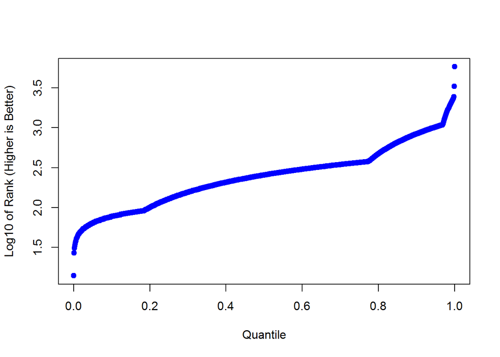

```r
plot(y=log10(quantile(storeStat[, 3], (0:1000)/1000)), x=(0:1000)/1000,
     pch=19, col="blue", xlab="Quantile", ylab="Log10 of Rank (Higher is Better)"
     )
```

```r
proc.time() - startTime
```

```
##    user  system elapsed
##   33.74    1.39   35.67
```

And, the hands are then played off against each other, with statistics kept for the “player” results. For these purposes, a very simple player strategy is adopted which will play anything J-3-2 or better. This is index 202 of hndType[[3]], corresponding to rank 176. So, the player will play all but the bottom 175 potential “best cards” in their hand.

Further, a simplifying assumption is made for this first pass that there is an infinite deck. As such, it is possible for the player and dealer to match a card:

```r
startTime <- proc.time()

# Find player qualifier
txtQual <- "11-3-2"
keyQual <- which(apply(hndType[[3]], 1, FUN=paste0, collapse="-") == txtQual)
keyScore <- hndScore[[3]][keyQual, 3]
cat("\n\nPlayer will play if equal to or better than ", txtQual, " which occurs at score index ", keyScore)
```

```
##
##
## Player will play if equal to or better than  11-3-2  which occurs at score index  176
```

```r
cat("\nHAND: ", hndType[[3]][keyQual, ], " with SCORE: ", hndScore[[3]][keyQual, ], "\n")
```

```
##
## HAND:  11 3 2  with SCORE:  3 2 176 1
```

```r
set.seed(1712110725)

nSims <- 5
sfTrack <- vector("list", nSims)
flTrack <- vector("list", nSims)
resTrack <- vector("list", nSims)

for (intCtr in 1:nSims) {
    # Sort the hands for playing two at a time
    playOrder <- sample(nTest, nTest, replace=FALSE)
    playNum <- seq_len(floor(length(playOrder) / 2))

    # Extract the player and dealer hands
    playStat <- storeStat[playOrder[rep(c(FALSE, TRUE), length(playNum))], ]
    dealStat <- storeStat[playOrder[rep(c(TRUE, FALSE), length(playNum))], ]

    # Extract the flushes and straight flushes for the player
    flPlay <- playStat[, 1]
    sfPlay <- playStat[, 2]

    # Extract whether the hands are playable for each of Dealer and Player
    qualPlay <- playStat[, 3] >= keyScore
    qualDeal <- dealStat[, 4] > 0

    # Determine the bet amount and results, assuming both sides have played (ignore qualification)
    betPlay <- 2 + ifelse(flPlay >= 5, 1, 0) + ifelse(flPlay >= 6, 1, 0)
    resGame <- integer(length(playNum))
    resWin <- playStat[, 3] > dealStat[, 3]
    resLose <- playStat[, 3] < dealStat[, 3]
    resTie <- playStat[, 3] == dealStat[, 3]

    # First, set the ties, wins, and losses, ignoring qualification and playability
    resGame[resTie] <- 0L
    resGame[resWin] <- betPlay[resWin]
    resGame[resLose] <- -betPlay[resLose]

    # Then, replace (over-write) any non-qualifiers with a +1 for the player
    resGame[!qualDeal] <- 1L

    # Then, replace (over-write) any non-playable hands with a -1 for the player
    resGame[!qualPlay] <- -1L

    # Store the data
    flTrack[[intCtr]] <- flPlay
    sfTrack[[intCtr]] <- sfPlay
    resTrack[[intCtr]] <- resGame

}

# for (intCtr in 1:nSims) {
#     # Sort the hands for playing two at a time
#     playOrder <- sample(nTest, nTest, replace=FALSE)
#     playNum <- seq_len(floor(length(playOrder) / 2))
#     sfTrack[[intCtr]] <- integer(length(playNum))
#     flTrack[[intCtr]] <- integer(length(playNum))
#     resTrack[[intCtr]] <- integer(length(playNum))
#     for (thisPlay in playNum) {
#         scrD <- storeStat[playOrder[2*thisPlay - 1], ]
#         scrP <- storeStat[playOrder[2*thisPlay], ]
#         flTrack[[intCtr]][thisPlay] <- scrP[1]
#         sfTrack[[intCtr]][thisPlay] <- scrP[2]
#         if (scrP[3] < keyScore) { tmpRes <- -1L }
#         else if (scrD[4] < 1) { tmpRes <- 1L }
#         else if (scrP[3] == scrD[3]) { tmpRes <- 0L }
#         else {
#             thisBet <- (2 + ifelse(scrP[1] >= 5, 1, 0) + ifelse(scrP[1] >= 6, 1, 0))
#             tmpRes <- ifelse(scrP[3] > scrD[3], 1, -1) * thisBet
#         }
#         resTrack[[intCtr]][thisPlay] <- tmpRes
#     }
# }

resTab <- t(sapply(resTrack, FUN=function(x) { tabulate(5+x, nbins=9) }))
colnames(resTab) <- -4:4
resTab / length(playNum)
```

```
##           -4        -3        -2        -1         0         1         2
## [1,] 4.0e-06 0.0004665 0.2177690 0.3379270 0.0010175 0.1632525 0.2569480
## [2,] 1.0e-06 0.0004845 0.2184760 0.3376915 0.0010000 0.1630630 0.2566830
## [3,] 3.5e-06 0.0004520 0.2186195 0.3375680 0.0010015 0.1630870 0.2567580
## [4,] 6.0e-06 0.0004480 0.2182350 0.3377885 0.0009870 0.1626875 0.2571335
## [5,] 1.0e-06 0.0004615 0.2185155 0.3381355 0.0010300 0.1630310 0.2561510
##              3         4
## [1,] 0.0210395 0.0015760
## [2,] 0.0210415 0.0015595
## [3,] 0.0209940 0.0015165
## [4,] 0.0211740 0.0015405
## [5,] 0.0210985 0.0015760
```

```r
sapply(resTrack, FUN=mean)
```

```
## [1] -0.0283095 -0.0303095 -0.0305260 -0.0289880 -0.0316225
```

```r
flTab <- t(sapply(flTrack, FUN=function(x) { tabulate(1+x, nbins=8) }))
colnames(flTab) <- 0:7
flTab / length(playNum)
```

```
##      0 1         2         3         4         5         6        7
## [1,] 0 0 0.1848535 0.5886440 0.1958920 0.0284945 0.0020605 5.55e-05
## [2,] 0 0 0.1845215 0.5895150 0.1953060 0.0285845 0.0020200 5.30e-05
## [3,] 0 0 0.1843420 0.5898035 0.1952760 0.0285415 0.0019820 5.50e-05
## [4,] 0 0 0.1844960 0.5895480 0.1952090 0.0286920 0.0019965 5.85e-05
## [5,] 0 0 0.1843230 0.5895700 0.1954875 0.0285645 0.0020015 5.35e-05
```

```r
sfTab <- t(sapply(sfTrack, FUN=function(x) { tabulate(1+x, nbins=8) }))
colnames(sfTab) <- 0:7
sfTab / length(playNum)
```

```
##              0 1         2         3         4         5        6 7
## [1,] 0.3924435 0 0.5378470 0.0643275 0.0050740 0.0002960 1.20e-05 0
## [2,] 0.3922995 0 0.5379455 0.0643460 0.0051020 0.0002935 1.35e-05 0
## [3,] 0.3922940 0 0.5380370 0.0642450 0.0051055 0.0003080 1.05e-05 0
## [4,] 0.3921470 0 0.5379020 0.0645620 0.0050740 0.0003030 1.20e-05 0
## [5,] 0.3922450 0 0.5379600 0.0643990 0.0050790 0.0003055 1.15e-05 0
```

```r
proc.time() - startTime
```

```
##    user  system elapsed
##    6.27    0.83    7.17
```

The influence of various hand types on the ability to achieve other hand types is further assessed:

```r
startTime <- proc.time()

# Convert to cards used
mtxUsed <- matrix(data=NA_integer_, nrow=0, ncol=13)
for (thisType in paste0("hndType", 1:7)) {
    thisData <- get(thisType)
    mtxCard <- matrix(data=NA_integer_, nrow=nrow(thisData), ncol=13)
    for (intCtr in 2:14) {
        mtxCard[, intCtr-1] <- apply(thisData, 1, FUN=function(x) { intCtr %in% x })
    }
    mtxUsed <- rbind(mtxUsed, mtxCard)
}

# Run the checking process
mtxCheck <- (mtxUsed %*% t(mtxUsed)) == 0

# Find the matches that are OK
mtxOK <- matrix(data=NA_integer_, nrow=sum(mtxCheck), ncol=2)
idxCur <- 1L
for (intCtr in 1:nrow(mtxCheck)) {
    okRow <- which(mtxCheck[intCtr, ] == TRUE)
    mtxOK[idxCur:(idxCur + length(okRow) - 1), ] <-
        matrix(data=c(rep(intCtr, length(okRow)), okRow), ncol=2, byrow=FALSE)
    idxCur <- idxCur + length(okRow)
}

sum(is.na(mtxOK))
```

```
## [1] 0
```

```r
dim(mtxOK)
```

```
## [1] 1472198       2
```

```r
proc.time() - startTime
```

```
##    user  system elapsed
##    1.48    0.09    1.64
```

Next, a sample card deck is created for example hands:

```r
# startTime <- proc.time()
#
# cardMatrix <- matrix(data=rep(2:14, times=4), ncol=4, byrow=FALSE)
# cardMatrix
#
# nDeal <- 1000000
# nShow <- 20
# set.seed(1711290801)
# rndDraw <- vector("list", nDeal)
# rndCards <- vector("list", nDeal)
# rndSuits <- vector("list", nDeal)
# for (intCtr in 1:nDeal) {
#     rndDraw[[intCtr]] <- sort(sample(1:52, size=7, replace=FALSE), decreasing=TRUE)
#     rndCards[[intCtr]] <- cardMatrix[rndDraw[[intCtr]]]
#     rndSuits[[intCtr]] <- 1 + (rndDraw[[intCtr]] - 1) %/% 13
# }
#
# showCards <- sort(sample(1:nDeal, nShow, replace=FALSE))
# for (eachCard in showCards) {
#     cat("\nHAND: ", eachCard, ": ", rndDraw[[eachCard]], "  --  ",
#         rndCards[[eachCard]], "  --  ", rndSuits[[eachCard]]
#         )
# }
#
# for (intCtr in showCards) {
#     cardSuit1 <- rndCards[[intCtr]][rndSuits[[intCtr]] == 1]
#     cardSuit2 <- rndCards[[intCtr]][rndSuits[[intCtr]] == 2]
#     cardSuit3 <- rndCards[[intCtr]][rndSuits[[intCtr]] == 3]
#     cardSuit4 <- rndCards[[intCtr]][rndSuits[[intCtr]] == 4]
#     cardSuitNil <- rndCards[[intCtr]][!(rndSuits[[intCtr]] %in% 1:4)]
#     if (intCtr %in% showCards) {
#         cat("\nSUIT 1: ", cardSuit1, "\tSUIT 2: ", cardSuit2, "\tSUIT3: ", cardSuit3,
#             "\tSUIT 4: ", cardSuit4, "\tERRORS: ", cardSuitNil,"\n"
#             )
#     }
# }
#
# proc.time() - startTime
```

The “playable” hand is then determined, as is the length of straight flushes (if any) and existence of a 3-card 9-high or better:

```r
# rankHigher <- function(x) {
#     # Assume x to be a list of at least length 1 (guard for this later)
#     cL <- sapply(x, FUN=length)
#     vL <- vector("list", 8)
#     vL[[1]] <- cL
#     for (intCtr in seq_len(7)) {
#         vL[[1 + intCtr]] <- sapply(x, FUN=function(y) { y[intCtr] })
#     }
#     return(order(vL[[1]], vL[[2]], vL[[3]], vL[[4]],
#                  vL[[5]], vL[[6]], vL[[7]], vL[[8]],
#                  na.last=TRUE, decreasing=TRUE)
#            )
# }
#
# startTime <- proc.time()
#
# hndDetails <- vector("list", nDeal)
# for (intCtr in 1:nDeal) {
#     cardList <- vector("list", 4)
#     for (listCtr in 1:4) {
#         cardList[[listCtr]] <- rndCards[[intCtr]][rndSuits[[intCtr]] == listCtr]
#     }
#     sfCheck <- sapply(cardList, FUN=numSF, ckAce=TRUE)
#     flLength <- sapply(cardList, FUN=length)
#     playHand <- cardList[[rankHigher(cardList)[1]]]
#     # playHand <- c(14, 12, 10)
#     qualCheck <- (length(playHand) >= 4 | (length(playHand) == 3 & max(playHand) >= 9))
#     if (intCtr %in% showCards) {
#         cat("\nHAND ", intCtr, ": \t", "Max Flush: ", max(flLength),
#             "\tMax SF: ", max(sfCheck), "\tQUALIFY:  ", qualCheck, "\tPlay Hand: ", playHand
#         )
#     }
#     hndDetails[[intCtr]] <- list(maxFlush=max(flLength), maxSF=max(sfCheck),
#                               qualCheck=qualCheck, playHand=as.vector(playHand)
#                               )
# }
#
# proc.time() - startTime
```

Next, two hands are played off against each other, with a determination of winners and losers:

```r
# set.seed(1712020805)
#
# startTime <- proc.time()
#
# hndOrder <- sample(1:nDeal, nDeal, replace=FALSE)
# # hndOrder
#
# showFull <- sample(1:floor(0.5*nDeal), min(nShow, floor(0.5 * nDeal)), replace=FALSE)
# allResults <- integer(floor(0.5 * nDeal))
# for (intCtr in 1:floor(0.5*nDeal)) {
#     nP <- hndOrder[2 * intCtr - 1]
#     nD <- hndOrder[2 * intCtr]
#
#     cardP <- rndCards[[nP]]
#     suitP <- rndSuits[[nP]]
#     cardD <- rndCards[[nD]]
#     suitD <- rndSuits[[nD]]
#
#     if (hndDetails[[nP]]$maxFlush == 2 |
#         (hndDetails[[nP]]$maxFlush == 3 & max(hndDetails[[nP]]$playHand) < 11)) {
#         hndResult <- -1
#     } else if (hndDetails[[nD]]$qualCheck == FALSE) {
#         hndResult <- 1
#     } else {
#         pBet <- 2 + ifelse(hndDetails[[nP]]$maxFlush == 5, 1, 0) + ifelse(hndDetails[[nP]]$maxFlush > 5, 2, 0)
#         tmp <- rankHigher(list(hndDetails[[nP]]$playHand, hndDetails[[nD]]$playHand))
#         if (tmp[1] == 2) { hndResult <- -pBet }
#         else if (tmp[1] == 1) { hndResult <- pBet}
#         else { stop("PROBLEM!") }
#     }
#
#     allResults[intCtr] <- hndResult
#
#     if (intCtr %in% showFull) {
#         cat("\n\nPLAYER HAND (", nP,"): Suit 1: ", cardP[suitP == 1], "\tSuit 2: ", cardP[suitP == 2],
#             "\tSuit 3: ", cardP[suitP == 3], "\tSuit 4: ", cardP[suitP == 4]
#             )
#         cat("\nDEALER HAND  (", nD,"): Suit 1: ", cardD[suitD == 1], "\tSuit 2: ", cardD[suitD == 2],
#             "\tSuit 3: ", cardD[suitD == 3], "\tSuit 4: ", cardD[suitD == 4]
#             )
#         cat("\nPLAYER STATS: Max Flush: ", hndDetails[[nP]]$maxFlush, "\tMax SF: ",
#             hndDetails[[nP]]$maxSF, "\tPLAYING HAND: ", hndDetails[[nP]]$playHand
#             )
#         cat("\nDEALER STATS: Max Flush: ", hndDetails[[nD]]$maxFlush, "\tQUAL: ",
#             hndDetails[[nD]]$qualCheck, "\tPLAYING HAND: ", hndDetails[[nD]]$playHand
#             )
#         cat("\nRESULT OF HAND COMPARISONS: ", hndResult)
#     }
#
# }
#
# table(allResults)
# mean(allResults)
#
# proc.time() - startTime
```